# Cleaning_Explore

2023-10-20

# We first start by exploring the number of sites

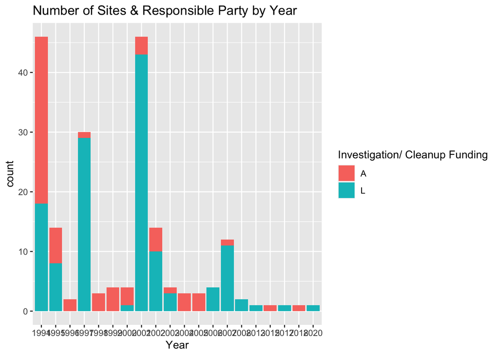

```
## # A tibble: 2 × 2
##   `Investigation/ Cleanup Funding`     n
##   <chr>                            <int>
## 1 A                                   17
## 2 L                                   75
```

```
## # A tibble: 4 × 2
##   Class     n
##   <chr> <int>
## 1 I         9
## 2 II       10
## 3 IV       70
## 4 V         3
```

There are a total of 196 sites that can obtain the funding that we are investigating.

Class breakdown: 9 class one 10 class two 70 class four 3 class five

# Now we want to look into how the population changed relative to the date of the spill

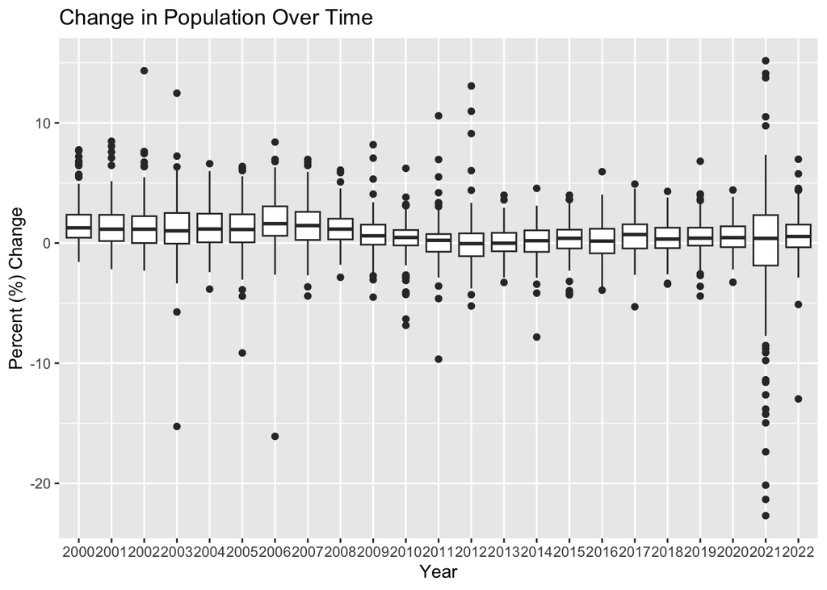

```r
# Clean up the long populatin dataset
long_population <- read_xlsx("health/Population_1999-2022.xlsx", skip = 1) %>%
  filter(!is.na(Geography)) %>%
  select(!`Selected Years Total`) %>%
  pivot_longer(cols = "1999":"2022", values_to = "population", names_to = "year")

long_population$year <- as.numeric(long_population$year)
long_population$population <- str_replace_all(long_population$population, ",", "")
long_population$population <- as.numeric(long_population$population)

# Calculate the year to year difference
# Sort to ensure that it is in order
long_population %>%
  arrange(Geography, year) %>%
  mutate(prev_year = lag(population)) %>%
  mutate(population_diff = population - prev_year) %>%
  mutate(percent_different = (population_diff / prev_year) * 100) %>%
  # Then we filter out 1999 because those will not be right
  filter(year != 1999) %>%
  ggplot(aes(x = as.factor(year), y = percent_different)) +
  geom_boxplot() +
  labs(title = "Change in Population Over Time",
       x = "Year",
       y = "Percent (%) Change")
```

```r
calculated_population <- long_population %>%
  arrange(Geography, year) %>%
  mutate(prev_year = lag(population)) %>%
  mutate(population_diff = population - prev_year) %>%
  mutate(percent_different = (population_diff / prev_year) * 100) %>%
  filter(year != 1999)

write.csv(calculated_population, "population_statistics_2000-2022.csv")
```

## Now we will join with the other dataset

Within this join we retain 90/93 sites

```r
calculated_population
```

```
## # A tibble: 3,749 × 6
##    Geography  year population prev_year population_diff percent_different
##    <chr>     <dbl>      <dbl>     <dbl>           <dbl>             <dbl>
##  1 Appling    2000      17396     17323              73            0.421
##  2 Appling    2001      17455     17396              59            0.339
##  3 Appling    2002      17502     17455              47            0.269
##  4 Appling    2003      17732     17502             230            1.31
##  5 Appling    2004      17740     17732               8            0.0451
##  6 Appling    2005      17769     17740              29            0.163
##  7 Appling    2006      17725     17769             -44           -0.248
##  8 Appling    2007      17985     17725             260            1.47
##  9 Appling    2008      18133     17985             148            0.823
## 10 Appling    2009      18144     18133              11            0.0607
## # ℹ 3,739 more rows
```

```r
sites_2001_2018_filtered <- sites_2001_2018_filtered %>%
  rename(c("year_site" = "year"))

# We have 90/93 sites represented
sites_2001_2018_filtered %>%
  inner_join(calculated_population, by = c("County" ="Geography")) %>%
  select(`HSI #`) %>%
  unique() %>%
  count()
```

```
## # A tibble: 1 × 1
##       n
##   <int>
## 1    90
```

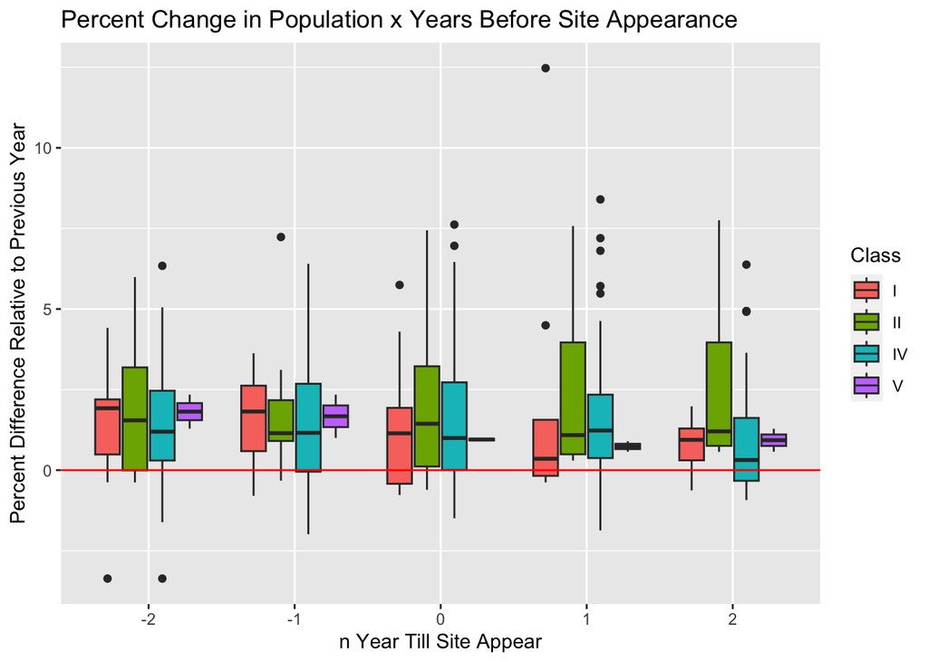

```r
pop_change_final_set <- sites_2001_2018_filtered %>%
  inner_join(calculated_population, by = c("County" ="Geography"))
pop_change_final_set$year_to_site <- (pop_change_final_set$year_site - pop_change_final_set$year)

pop_change_final_set %>%
  filter(year_to_site <= 2 & year_to_site >= -2) %>%
  ggplot(aes(x = factor(year_to_site), y = percent_different, fill = Class)) +
  geom_boxplot() +
  geom_hline(yintercept = 0, color = "red") +
  labs(title = "Percent Change in Population x Years Before Site Appearance",
       x = "n Year Till Site Appear",
       y = "Percent Difference Relative to Previous Year")
```

I won’t even bothering doing stat tests… Unlikely to find sig. change

# I will now begin to explore health variables

## Start with ADRD

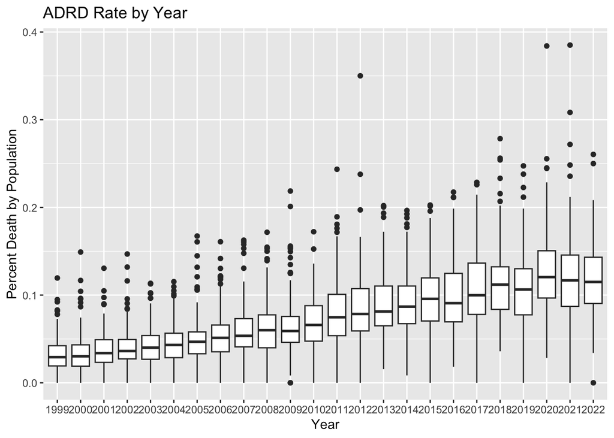

```r
ADRD <- read_xlsx("health/ADRD_1999-2022.xlsx", skip = 1) %>%
  filter(!is.na(Geography)) %>%
  select(!`Selected Years Total`) %>%
  pivot_longer(cols = "1999":"2022", values_to = "deaths", names_to = "year")

ADRD$year <- as.numeric(ADRD$year)

ADRD <- ADRD %>%
  left_join(long_population, by = c("Geography" = "Geography", "year" = "year"))

ADRD$deaths <- str_replace_all(ADRD$deaths, ",", "")

ADRD$deaths <- as.numeric(ADRD$deaths)

ADRD <- ADRD %>%
  mutate(rate = (deaths / population) * 100)

ADRD %>%
  arrange(Geography, year) %>%
  ggplot(aes(x = as.factor(year), y = rate)) +
  geom_boxplot() +
  labs(title = "ADRD Rate by Year",
       x = "Year",
       y = "Percent Death by Population")
```

## Look at the time-based change. Calculate the change from year to year (90/93)

```r
ADRD_joined <- sites_2001_2018_filtered %>%
  inner_join(ADRD, by = c("County" ="Geography"))
mean((ADRD %>%
  anti_join(sites_2001_2018_filtered, by = c("Geography" ="County")) %>%
  arrange(Geography, year) %>%
  mutate(prev_rate = lag(rate)) %>%
  mutate(rate_diff = rate - prev_rate) %>%
  mutate(percent_different = (rate_diff / prev_rate) * 100) %>%
  filter(year != 1999) %>%
    filter(percent_different != Inf) %>%
    filter(population > 1000))$percent_different, na.rm = T)
```

```
## [1] 18.20874
```

```r
# We note the extremely high SD and will explore its origins at a later date
sd((ADRD %>%
  anti_join(sites_2001_2018_filtered, by = c("Geography" ="County")) %>%
  arrange(Geography, year) %>%
  mutate(prev_rate = lag(rate)) %>%
  mutate(rate_diff = rate - prev_rate) %>%
  mutate(percent_different = (rate_diff / prev_rate) * 100) %>%
  filter(year != 1999) %>%
    filter(percent_different != Inf) %>%
    filter(population > 1000))$percent_different, na.rm = T)
```

```
## [1] 72.13763
```

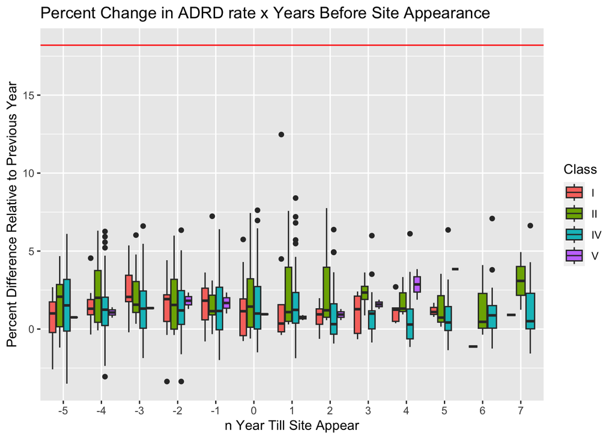

```r
ADRD_joined <- ADRD_joined %>%
  arrange(County, year) %>%
  mutate(prev_rate = lag(rate)) %>%
  mutate(rate_diff = rate - prev_rate) %>%
  mutate(percent_different = (rate_diff / prev_rate) * 100) %>%
  filter(year != 1999)

ADRD_joined$year_to_site <- (ADRD_joined$year_site - ADRD_joined$year)

pop_change_final_set %>%
  filter(year_to_site <= 7 & year_to_site >= -5) %>%
  ggplot(aes(x = factor(year_to_site), y = percent_different, fill = Class)) +
  geom_boxplot() +
  geom_hline(yintercept = 18.2, color = "red") +
  labs(title = "Percent Change in ADRD rate x Years Before Site Appearance",
       x = "n Year Till Site Appear",
       y = "Percent Difference Relative to Previous Year")
```

```r
write.csv(ADRD_joined, "ADRD_deaths_2000-2022.csv")
```

## Next we Look at Alzheimers

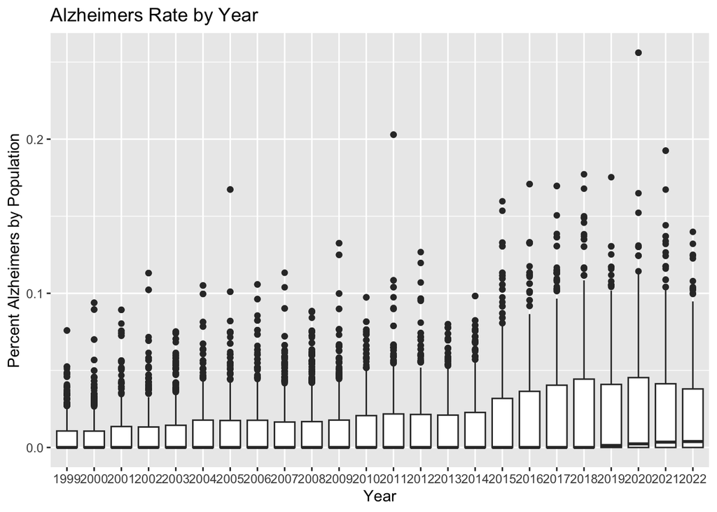

```r
ADRD <- read_xlsx("health/Alzheimers_1999-2022.xlsx", skip = 1) %>%
  filter(!is.na(Geography)) %>%
  select(!`Selected Years Total`) %>%
  pivot_longer(cols = "1999":"2022", values_to = "deaths", names_to = "year")

ADRD$year <- as.numeric(ADRD$year)

ADRD <- ADRD %>%
  left_join(long_population, by = c("Geography" = "Geography", "year" = "year"))

ADRD$deaths <- str_replace_all(ADRD$deaths, ",", "")

ADRD$deaths <- as.numeric(ADRD$deaths)

ADRD <- ADRD %>%
  mutate(rate = (deaths / population) * 100)

ADRD %>%
  arrange(Geography, year) %>%
  ggplot(aes(x = as.factor(year), y = rate)) +
  geom_boxplot() +
  labs(title = "Alzheimers Rate by Year",
       x = "Year",
       y = "Percent Alzheimers by Population")
```

```r
ADRD_joined <- sites_2001_2018_filtered %>%
  inner_join(ADRD, by = c("County" ="Geography"))
mean((ADRD %>%
  anti_join(sites_2001_2018_filtered, by = c("Geography" ="County")) %>%
  arrange(Geography, year) %>%
  mutate(prev_rate = lag(rate)) %>%
  mutate(rate_diff = rate - prev_rate) %>%
  mutate(percent_different = (rate_diff / prev_rate) * 100) %>%
  filter(year != 1999) %>%
    filter(percent_different != Inf) %>%
    filter(population > 1000))$percent_different, na.rm = T)
```

```
## [1] 106.1227
```

```r
# We note the extremely high SD and will explore its origins at a later date
sd((ADRD %>%
  anti_join(sites_2001_2018_filtered, by = c("Geography" ="County")) %>%
  arrange(Geography, year) %>%
  mutate(prev_rate = lag(rate)) %>%
  mutate(rate_diff = rate - prev_rate) %>%
  mutate(percent_different = (rate_diff / prev_rate) * 100) %>%
  filter(year != 1999) %>%
    filter(percent_different != Inf) %>%
    filter(population > 1000))$percent_different, na.rm = T)
```

```
## [1] 6988.644
```

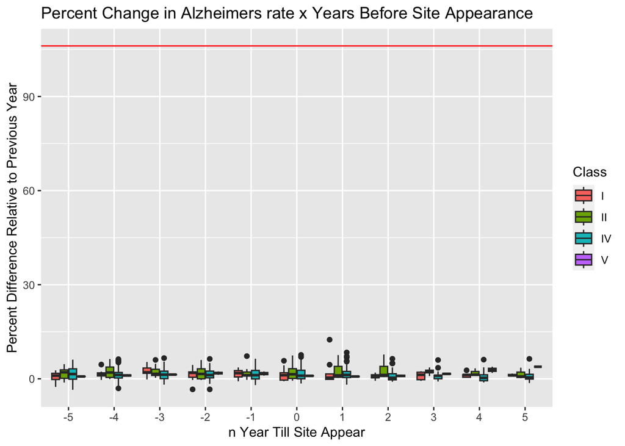

```r
ADRD_joined <- ADRD_joined %>%
  arrange(County, year) %>%
  mutate(prev_rate = lag(rate)) %>%
  mutate(rate_diff = rate - prev_rate) %>%
  mutate(percent_different = (rate_diff / prev_rate) * 100) %>%
  filter(year != 1999)

ADRD_joined$year_to_site <- (ADRD_joined$year_site - ADRD_joined$year)

pop_change_final_set %>%
  filter(year_to_site <= 5 & year_to_site >= -5) %>%
  ggplot(aes(x = factor(year_to_site), y = percent_different, fill = Class)) +
  geom_boxplot() +
  geom_hline(yintercept = 106.12, color = "red") +
  labs(title = "Percent Change in Alzheimers rate x Years Before Site Appearance",
       x = "n Year Till Site Appear",
       y = "Percent Difference Relative to Previous Year")
```

```r
write.csv(ADRD_joined, "Alzheimers_rate_2000-2022.csv")
```

Situation of actually more cases or are there simply more being reported per capita?

Maybe a better method for analysis will use Regression discontinuity for group of sites impacted one year, and then compare to another?

This mostly about cleaning and explore so OK.

## Finally, we look at infant deaths

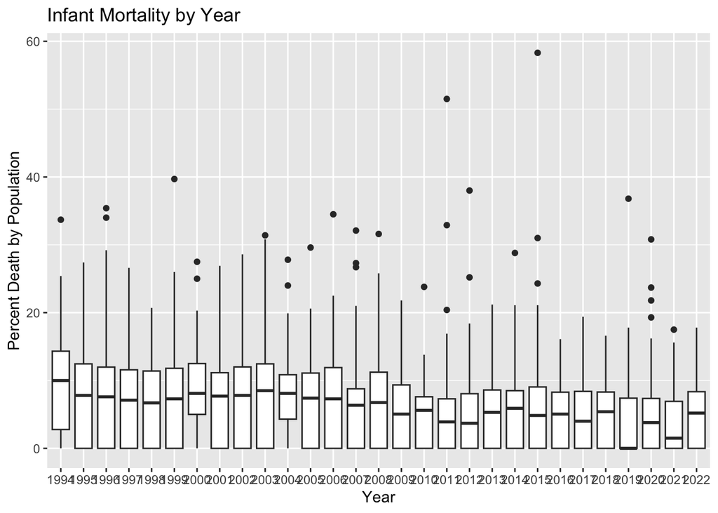

```r
ADRD <- read_xlsx("health/Infant_Mortality_1994-2022.xlsx", skip = 1) %>%
  filter(!is.na(Geography)) %>%
  select(!`Selected Years Total`) %>%
  pivot_longer(cols = "1994":"2022", values_to = "rate", names_to = "year")

ADRD$year <- as.numeric(ADRD$year)

ADRD <- ADRD %>%
  left_join(long_population, by = c("Geography" = "Geography", "year" = "year"))

ADRD$rate <- str_replace_all(ADRD$rate, ",", "")

# note that lots of NA values
ADRD$rate <- as.numeric(ADRD$rate)
ADRD %>%
  arrange(Geography, year) %>%
  ggplot(aes(x = as.factor(year), y = rate)) +
  geom_boxplot() +
  labs(title = "Infant Mortality by Year",
       x = "Year",
       y = "Percent Death by Population")
```

```r
ADRD_joined <- sites_2001_2018_filtered %>%
  inner_join(ADRD, by = c("County" ="Geography"))
ADRD_joined <- ADRD_joined %>%
  drop_na()

# 4.6
mean((ADRD %>%
  anti_join(sites_2001_2018_filtered, by = c("Geography" ="County")) %>%
  arrange(Geography, year) %>%
  mutate(prev_rate = lag(rate)) %>%
  mutate(rate_diff = rate - prev_rate) %>%
  mutate(percent_different = (rate_diff / prev_rate) * 100) %>%
  filter(year != 1994) %>%
    filter(percent_different != Inf) %>%
    filter(population > 1000))$percent_different, na.rm = T)
```

```
## [1] 5.368447
```

```r
# We note the extremely high SD and will explore its origins at a later date
sd((ADRD %>%
  anti_join(sites_2001_2018_filtered, by = c("Geography" ="County")) %>%
  arrange(Geography, year) %>%
  mutate(prev_rate = lag(rate)) %>%
  mutate(rate_diff = rate - prev_rate) %>%
  mutate(percent_different = (rate_diff / prev_rate) * 100) %>%
  filter(year != 1994) %>%
    filter(percent_different != Inf) %>%
    filter(population > 1000))$percent_different, na.rm = T)
```

```
## [1] 44.40975
```

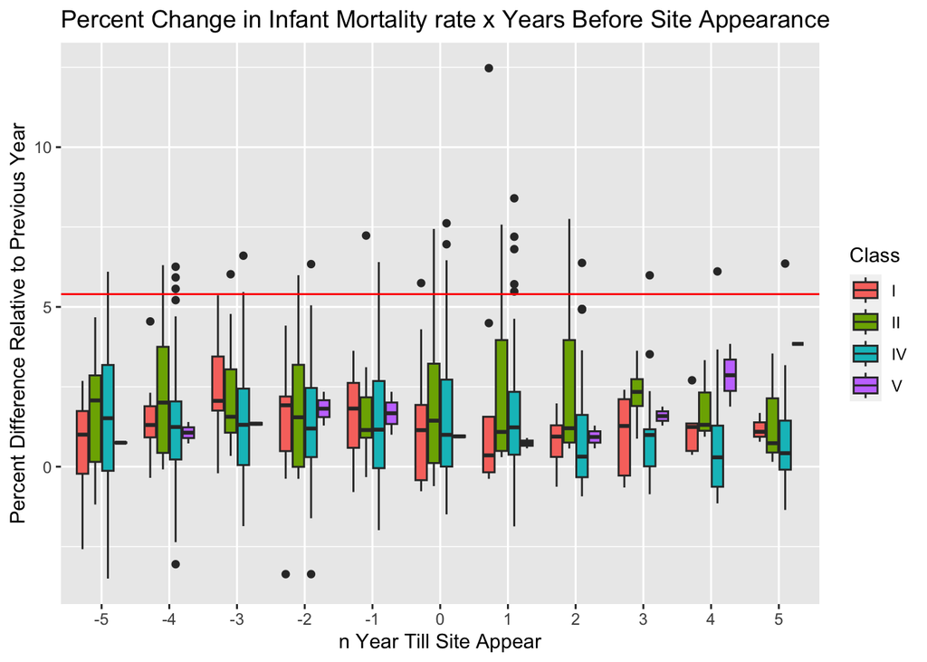

```r
ADRD_joined <- ADRD_joined %>%
  arrange(County, year) %>%
  mutate(prev_rate = lag(rate)) %>%
  mutate(rate_diff = rate - prev_rate) %>%
  mutate(percent_different = (rate_diff / prev_rate) * 100) %>%
  filter(year != 1994)

ADRD_joined$year_to_site <- (ADRD_joined$year_site - ADRD_joined$year)

pop_change_final_set %>%
  filter(year_to_site <= 5 & year_to_site >= -5) %>%
  ggplot(aes(x = factor(year_to_site), y = percent_different, fill = Class)) +
  geom_boxplot() +
  geom_hline(yintercept = 5.4, color = "red") +
  labs(title = "Percent Change in Infant Mortality rate x Years Before Site Appearance",
       x = "n Year Till Site Appear",
       y = "Percent Difference Relative to Previous Year")
```

```r
write.csv(ADRD_joined, "Infant_Mortality_2000-2022.csv")
```